# Assignment3

## Q1

[figure not shown]

When the front wheel rotates $\theta$, the rear wheel rotates $2\theta$. Assume there is a frame {b'} at the center of front wheel parallel to the world frame and a frame{a'} at the center of rear wheel parallel to the world frame.

$$ \begin{aligned} ^{b'}T_c &= \begin{bmatrix} 1&0&0&0\\ 0&1&0&0\\ 0&0&1&r\\ 0&0&0&1\\ \end{bmatrix} \\ ^{a'}T_{b'} &= \begin{bmatrix} 1&0&0&0\\ 0&1&0&L\\ 0&0&1&r\\ 0&0&0&1\\ \end{bmatrix} \\ ^{a}T_{a'} &= \begin{bmatrix} 1&0&0&0\\ 0&cos(2\theta)&-sin(2\theta)&0\\ 0&sin(2\theta)&cos(2\theta)&0\\ 0&0&0&1\\ \end{bmatrix}\\ ^{a}T_{c} &= ^{a}T_{a'} ^{a'}T_{b'} ^{b'}T_{c}\\ &= \begin{bmatrix} 1&0&0&0\\ 0&cos(2\theta)&-sin(2\theta)&Lcos(2\theta)-2rsin(2\theta)\\ 0&sin(2\theta)&cos(2\theta)&Lsin(2\theta)+2rcos(2\theta )\\ 0&0&0&1\\ \end{bmatrix} \end{aligned} $$

## Q2

[figure not shown]

(1) $$ \begin{aligned} ^{0}T_{2} &= \begin{bmatrix} \frac{\sqrt{2}}{2}&\frac{\sqrt{2}}{2}&0&1-\sqrt{2}+v_1 t \frac{\sqrt{2}}{2}\\ \frac{-\sqrt{2}}{2}&\frac{\sqrt{2}}{2}&0&1+\sqrt{2}-v_1 t \frac{\sqrt{2}}{2}\\ 0&0&1&2\\ 0&0&0&1 \end{bmatrix} \

\end{aligned} $$ (2) $$ ^{1}T_{2} = {^{1}T_{0}} {^{0}T_{2}} $$ And $$ ^1T_{0} = \begin{bmatrix} ^1R_0^{T}& -{^{1}R_0}^{T} {^1p_0}\\ 0&1 \end{bmatrix} $$

## Q3

[figure not shown]

```
rotation direction=[ 0.          0.         57.29577951] in deg
axis translation=[3 0 0]
screw pitch = 2
rotation speed=2
```

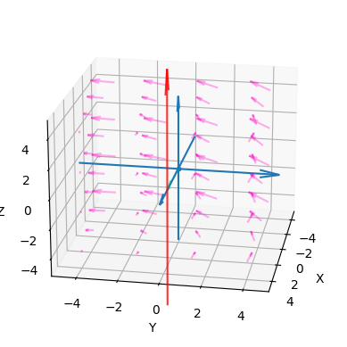

```python
import numpy as np
import matplotlib.pyplot as plt
%matplotlib inline
q = np.array([3,0,0])
s = np.array([0,0,1])
h = 2
theta_d = 2
w = s*theta_d
v = -np.cross(s*theta_d,q)+h*s*theta_d
print('rotation direction={} in deg'.format(s*180/np.pi))
print('axis translation={}'.format(q))
print('screw pitch = {}'.format(h))
print('rotation speed={}'.format(theta_d))
L = 4
fig = plt.figure()
ax = plt.axes(projection='3d')
ax.grid()
ax.quiver(-5,0,0,1,0,0,normalize=True,length=10,arrow_length_ratio=0.1)
ax.quiver(0,-5,0,0,1,0,normalize=True,length=10,arrow_length_ratio=0.1)
ax.quiver(0,0,-5,0,0,1,normalize=True,length=10,arrow_length_ratio=0.1)
ax.quiver(0,0,0,q[0],q[1],q[2],normalize=True,length=np.linalg.norm(q),color=(0,1,0.5,0.7))
ax.quiver(q[0]-s[0]*2*L,q[1]-s[1]*2*L,q[2]-s[2]*2*L,s[0],s[1],s[2],
          normalize=True,length=4*L,arrow_length_ratio=0.1,color=(1, 0, 0, 0.8))
ax.scatter(0,0,0,'linewidth',10)
ax.set_xlabel('X')
ax.set_xlim3d(-5, 5)
ax.set_ylabel('Y')
ax.set_ylim3d(-5, 5)
ax.set_zlabel('Z')
ax.set_zlim3d(-5, 5)
x = np.linspace(-4,4,4)
y = np.linspace(-4,4,4)
z = np.linspace(-4,4,4)
x_,y_,z_ = np.meshgrid(x,y,z)
x_ = np.reshape(x_,(1,np.size(x_)))
y_ = np.reshape(y_,(1,np.size(y_)))
z_ = np.reshape(z_,(1,np.size(z_)))
p = np.vstack([x_,y_,z_])
v_ = np.zeros((3,np.size(x_)))
for i in range(np.size(x_)):
    v_[:,i] = v+np.cross(w,p[:,i])
    ax.quiver(x_[:,i],y_[:,i],z_[:,i],v_[0,i],v_[1,i],v_[2,i],normalize=True,length=0.08*np.linalg.norm(v_[:,i]),
              color=(1,0,0.8,0.3),arrow_length_ratio=0.4)
ax.view_init(elev=20, azim=10)
plt.show()
```

## Q4

[figure not shown]

$\omega _b$ is the angular velocity in {b} frame, and $\omega _s$ is the angular velocity expressed in {s} frame. The rotation matrix $^{s}R_b$ is given.

```python
R = np.array([[0,-1,0],[0,0,-1],[1,0,0]])
ws = np.array([1,2,3])
wb = np.matmul(R.T,ws.T)
print(wb)
```

```
[ 3 -1 -2]
```

## Q5

[figure not shown]

### (a)

Position of point P $$ ^{s}p = ^{s}\overrightarrow{OP} = [L+dsin\theta,L-dcos\theta]^T $$

### (b)

Velocity of point P $$ \frac{d {^{s}p}}{dt} = [dcos\theta, dsin\theta,0]^T $$

### (c)

The configuration of {b} seen from {s} is $$ ^{s}T_{b} = \begin{bmatrix} ^{s}R_b & ^{s}p_b\\ 0&1 \end{bmatrix} = \begin{bmatrix} c_\theta& -s_\theta& 0&L+ds_\theta \\ s_\theta& c_\theta& 0& L-dc_\theta\\ 0& 0& 1& 0\\ 0& 0& 0& 1 \end{bmatrix} $$

### (d)

Let the point r be the body fixed point in rotation axis.

The velocity of body fixed point corresponds to $O_b$ is $$ ^{b}v_p = ^{b}v_r+^b\omega \times ^{b}\overrightarrow{ro_b} = [d,0,0]^{T} $$

The twist of $^{s}T_b$ in {b} is $$ ^b\nu = [0,0,1,d,0,0] $$

### (e)

The velocity of body fixed point corresponds to $O_s$ is $$ ^{s}v_{o_s} = ^{s}v_r+^s\omega \times ^{s}\overrightarrow{ro_s} = [L,-L,0]^{T} $$

The twist of $^{s}T_b$ in {s} is $$ ^s\nu = [0,0,1,L,-L,0] $$

### (f)

$$ \begin{align} ^{s}\omega =& ^{s}R_{b} {^{b}\omega} \\ ^{s}v_{o_b} =& ^{s}R_{b} {^{b}v_{o_b}}+[^{s}p_b]{^{s}R_{b}} {^{b}\omega} \end{align} $$

### (g)

The linear velocity part of twist $^{b}\nu$ is $\dot{p}$ expressed in {b} frame.

### (h)

The linear velocity part of twist $^{s}\nu$ is $\dot{p} - ^{s}\omega \times p$.

## Q6

[figure not shown]

(1) The first step is to calculate the transformation matrix $^{s}T_b$. Assume at $t=0$, $\hat{x_b}$ has the same direction with $\hat{x_s}$. And there is a coordinate system {c} at the center of the plate and fixed to the penperdicular shaft.

$$ ^{s}T_{c} = \begin{bmatrix} cos(t)&0&sin(t)&-10sin(t)\\ 0&1&0&0\\ -sin(t)&0&cos(t)&-10cos(t)\\ 0&0&0&1 \end{bmatrix} $$

And $$ ^{c}T_{b} = \begin{bmatrix} cos(t)&-sin(t)&0&20cos(t)\\ sin(t)&cos(t)&0&20sin(t)\\ 0&0&1&0\\ 0&0&0&1 \end{bmatrix} $$ Then $$ ^{s}T_{b} = {^{s}T_c}{^{c}T_{b}} \begin{bmatrix} cos^2(t)&-cos(t)sin(t)&sin(t)&20cos^2(t)-10sin(t)\\ sin(t)&cos(t)&0&20sin(t)\\ -cos(t)sin(t)&sin^2(t)&cos(t)&-20sin(t)*cos(t)-10cos(t)\\ 0&0&0&1 \end{bmatrix} $$ And $$ {^{s}T_b}^{-1}\dot{^{s}T_b} = \begin{bmatrix} [\omega _b] &v_b\\ 0&0 \end{bmatrix} $$

$$ {^{s}T_b}^{-1} = \begin{bmatrix} c^2&s&-cs&-20\\ -cs&c&s^2& 0\\ s&0&c&10\\ 0&0&0&1 \end{bmatrix} $$$$ \dot{^{s}T_b} = \begin{bmatrix} -2cs& s^2-c^2& c& -40cs-10c\\ c&-s&0&20c\\ s^2-c^2&2cs&-s&20s^2-20c^2+10s\\ 0&0&0&0 \end{bmatrix} $$$$ {^{s}T_b}^{-1}\dot{^{s}T_b} = \begin{bmatrix} 0 & -1& c & -10c \\ 1 & 0 & -s & 10s+20 \\ -c& s & 0 & -20c\\ 0& 0& 0& 0 \end{bmatrix} $$

```python
from sympy import*
t = symbols('t')
tsc = Matrix([[cos(t),0,sin(t),-10*sin(t)],[0,1,0,0],[-sin(t),0,cos(t),-10*cos(t)],[0,0,0,1]])
tcb = Matrix([[cos(t),-sin(t),0,20*cos(t)],[sin(t),cos(t),0,20*sin(t)],[0,0,1,0],[0,0,0,1]])
tsb = tsc.multiply(tcb)
print("Tsb=")
pprint(tsb)
tsb_inv = tsb.inv()
print("Tsb -1 = ")
pprint(simplify(tsb_inv))
diff_tsb = diff(tsb,t)
print("diff(Tsb) = ")
pprint(simplify(diff_tsb))
Vb = tsb_inv.multiply(diff_tsb)
print("Vb = ")
pprint(simplify(Vb))
```

```
Tsb=
⎡      2                                                       2      ⎤
⎢   cos (t)      -sin(t)⋅cos(t)  sin(t)     -10⋅sin(t) + 20⋅cos (t)   ⎥
⎢                                                                     ⎥
⎢    sin(t)          cos(t)        0               20⋅sin(t)          ⎥
⎢                                                                     ⎥
⎢                      2                                              ⎥
⎢-sin(t)⋅cos(t)     sin (t)      cos(t)  -20⋅sin(t)⋅cos(t) - 10⋅cos(t)⎥
⎢                                                                     ⎥
⎣      0               0           0                   1              ⎦
Tsb -1 =
⎡    2               -sin(2⋅t)      ⎤
⎢ cos (t)    sin(t)  ──────────  -20⎥
⎢                        2          ⎥
⎢                                   ⎥
⎢-sin(2⋅t)               2          ⎥
⎢──────────  cos(t)   sin (t)     0 ⎥
⎢    2                              ⎥
⎢                                   ⎥
⎢  sin(t)      0       cos(t)    10 ⎥
⎢                                   ⎥
⎣    0         0         0        1 ⎦
diff(Tsb) =
⎡-sin(2⋅t)  -cos(2⋅t)  cos(t)   -10⋅(4⋅sin(t) + 1)⋅cos(t)⎤
⎢                                                        ⎥
⎢ cos(t)     -sin(t)      0             20⋅cos(t)        ⎥
⎢                                                        ⎥
⎢-cos(2⋅t)  sin(2⋅t)   -sin(t)   10⋅sin(t) - 20⋅cos(2⋅t) ⎥
⎢                                                        ⎥
⎣    0          0         0                 0            ⎦
Vb =
⎡   0       -1    cos(t)     -10⋅cos(t)  ⎤
⎢                                        ⎥
⎢   1       0     -sin(t)  10⋅sin(t) + 20⎥
⎢                                        ⎥
⎢-cos(t)  sin(t)     0       -20⋅cos(t)  ⎥
⎢                                        ⎥
⎣   0       0        0           0       ⎦
```

$$ \omega _b = [sin(t),cos(t),1]^T \\ v_b = [-10cos(t),10sin(t)+20,-20cos(t)]^T $$

(2) $\dot{p}$ can be calculated directly using $^sT_b$. Or we can use twist $$ \dot{^{s}T_b}{^{s}T_b}^{-1} = \begin{bmatrix} [\omega _s] &v_s\\ 0&0 \end{bmatrix} = \begin{bmatrix} 0 & -cos(t) & 1 & 0\\ cos(t) & 0 & -sin(t) & 0\\ -1 & sin(t) & 0 & 0\\ 0 & 0 & 0 & 0 \end{bmatrix} $$ And $$ \omega _s = [sin(t),1,cos(t)]^T v_s = [0,0,0]^T $$ The $v_s$ is not the linear velocity, it represents the instantaneous velocity of the point on the body currently at the fixed-frame origin. $$ v_s = \dot{p}-\omega _s \times p = 0\\ \dot{p} = [\omega _s] p = [-40cs-10c,20c,-20c^2+20s^2+10s] $$

```python
Vs = diff_tsb.multiply(tsb_inv)
print("Vs = ")
pprint(simplify(Vs))
p = tsb[0:3,3]
print("p = ")
pprint(simplify(p))
diff_p = Vs[0:3,0:3].multiply(p)
print("diff_p = ")
pprint(simplify(diff_p))
```

```
Vs =
⎡  0     -cos(t)     1     0⎤
⎢                           ⎥
⎢cos(t)     0     -sin(t)  0⎥
⎢                           ⎥
⎢  -1    sin(t)      0     0⎥
⎢                           ⎥
⎣  0        0        0     0⎦
p =
⎡                   2    ⎤
⎢-10⋅sin(t) + 20⋅cos (t) ⎥
⎢                        ⎥
⎢       20⋅sin(t)        ⎥
⎢                        ⎥
⎣-10⋅sin(2⋅t) - 10⋅cos(t)⎦
diff_p =
⎡-10⋅(4⋅sin(t) + 1)⋅cos(t)⎤
⎢                         ⎥
⎢        20⋅cos(t)        ⎥
⎢                         ⎥
⎣ 10⋅sin(t) - 20⋅cos(2⋅t) ⎦
```